## Wader abundance trends

### Tuning model hyper parameters

The tuning grid over 10 different folds gave the results for the different hyper parameter permutations as shown in Figure @ref(fig:showTuneResults) - each figure show the results for a particular species. Each parameter is plotted against the resulting root mean squared error (rmse).

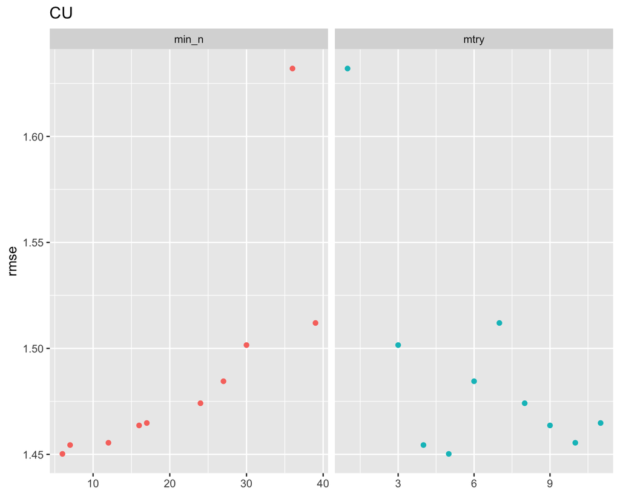

Root mean squared evaluation of hyper parameters across all species

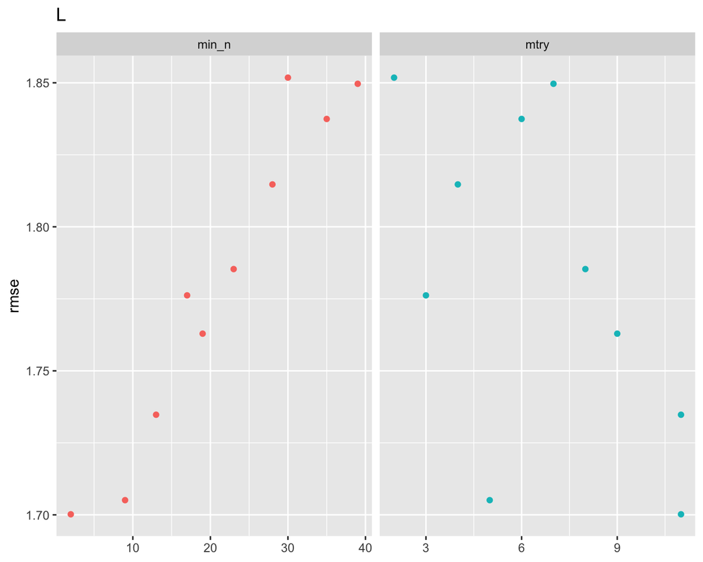

Root mean squared evaluation of hyper parameters across all species

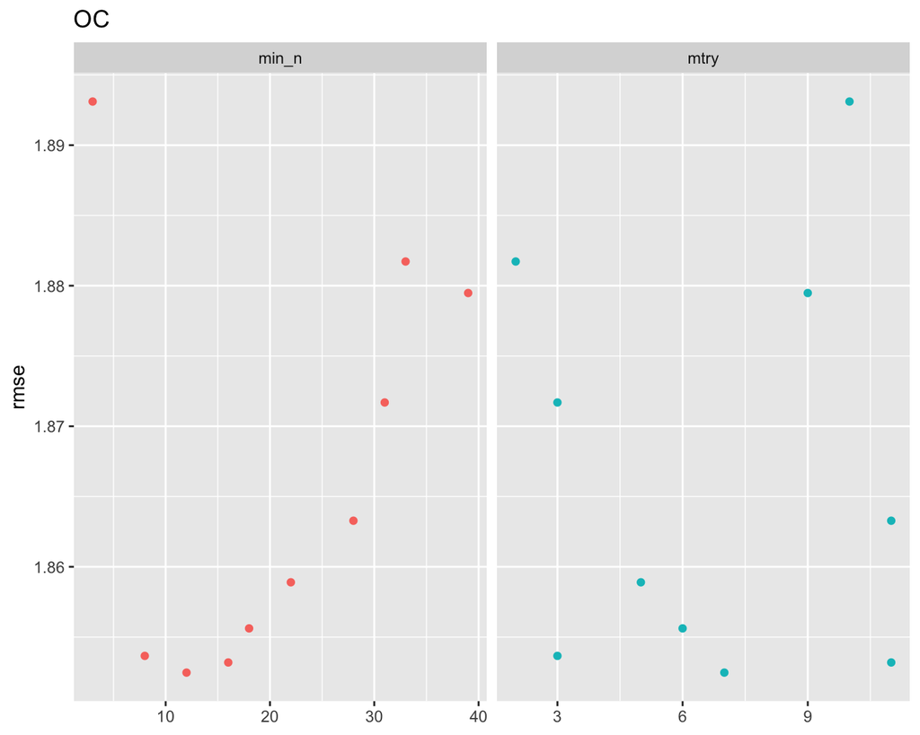

Root mean squared evaluation of hyper parameters across all species

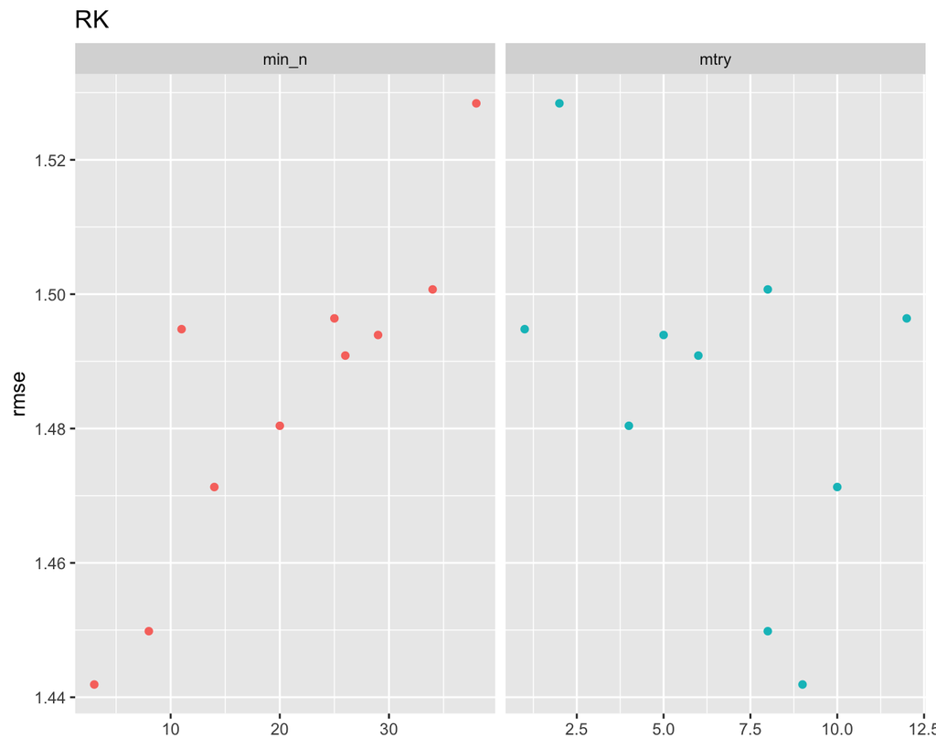

Root mean squared evaluation of hyper parameters across all species

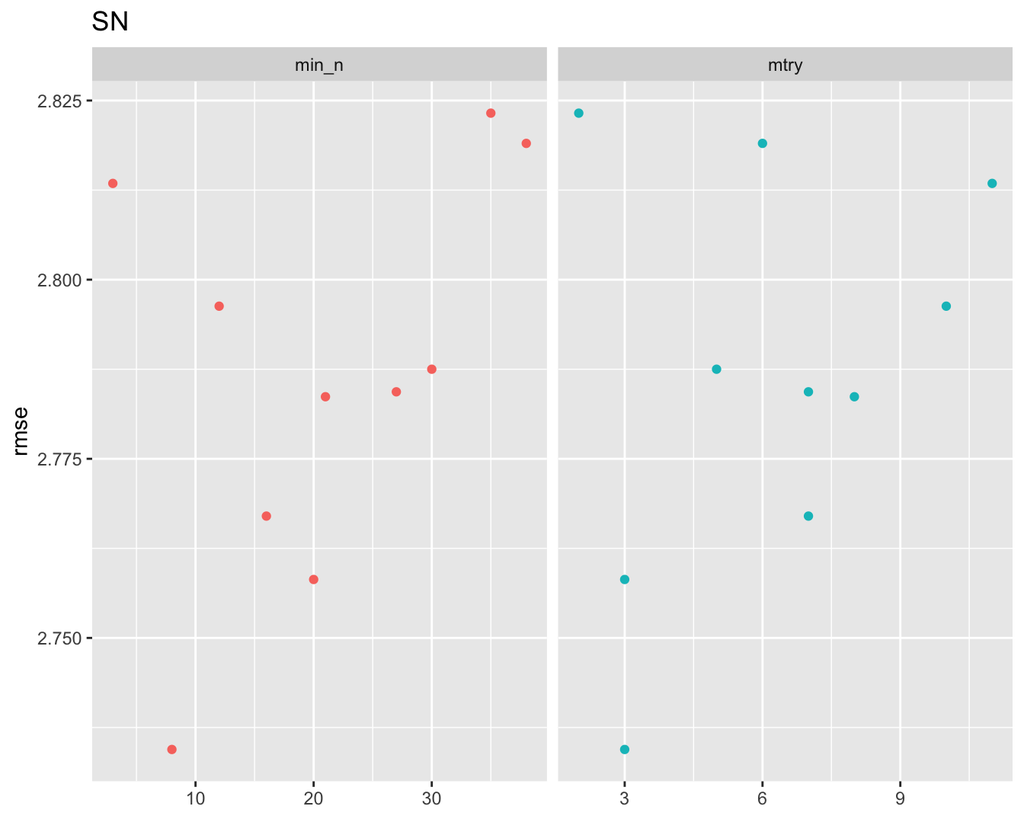

Root mean squared evaluation of hyper parameters across all species

### Further model hyper parameter tuning

The model fit was refined further by searching over a revised hypergrid range for each species. The range used was that which gave the lowest rmse as given in Figure @ref(fig:showTuneResults). The results of the revised tuning grid can be seen in Figure @ref(fig:plotRetuneResults).

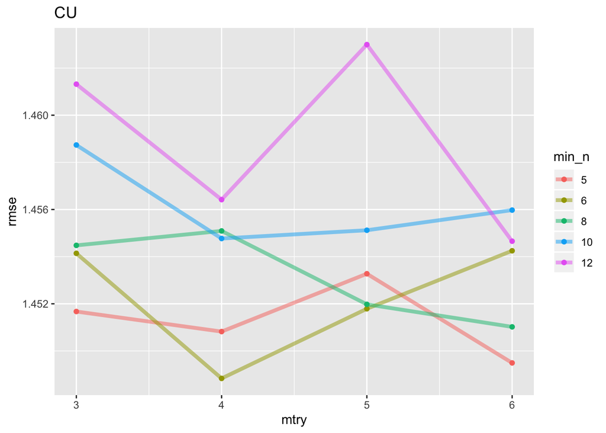

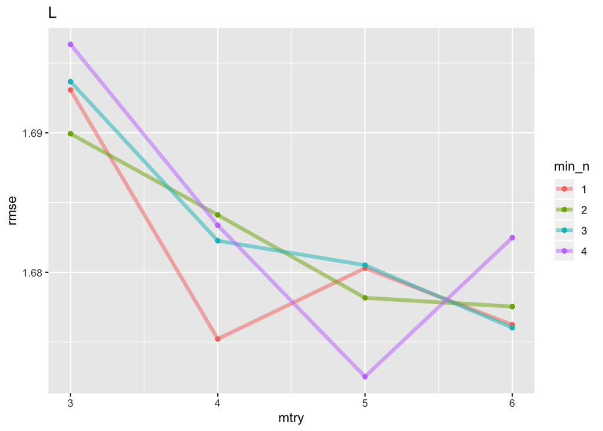

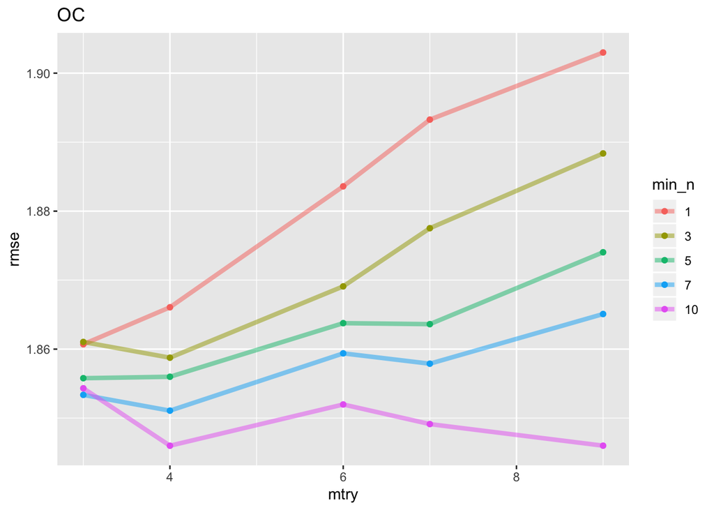

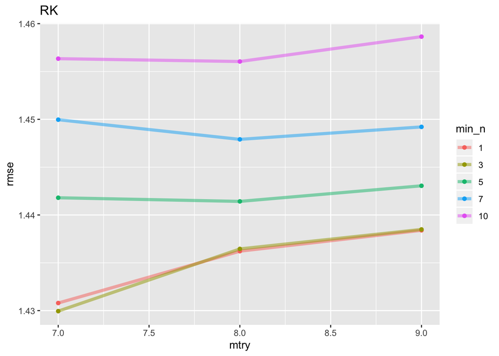

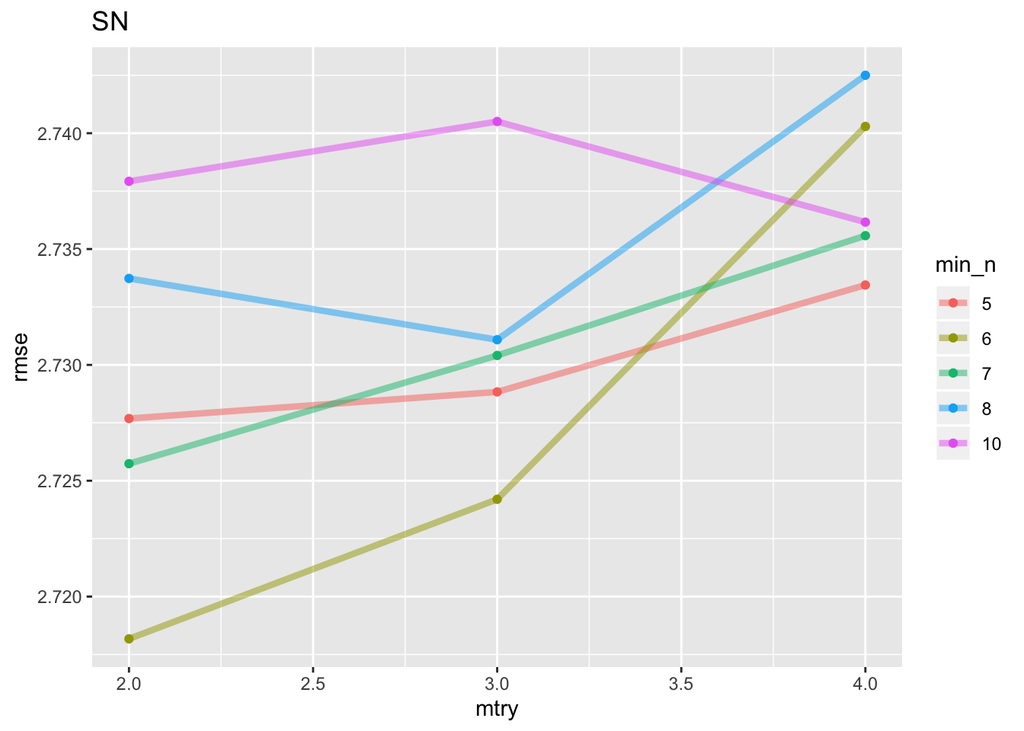

From the plot above we can see which hyper parameters give the best fit, when using root mean squared error as an evaluation metric. It can be seen that the model fit for Snipe has the largest RMSE and Redshank, the lowest. For each species the minimum rmse given by the best model fit, together with the associated hyper parameters (`trees`= 1000 for all models) is shown in Table @ref(tab:bestByRMSE).

| Species | mtry | min_n | rmse |
| --- | --- | --- | --- |
| CU | 4 | 6 | 1.448835 |
| L | 5 | 4 | 1.672523 |
| OC | 4 | 10 | 1.845994 |
| RK | 7 | 3 | 1.429948 |
| SN | 2 | 6 | 2.718174 |

### Variable importance in model fit

Having selected the best model fit the variable importance for each species was assessed. The `r` `vip` package can be used to explore the relative importance of different covariates in the model fit. The results are shown in Figure @ref(fig:variableImportance).

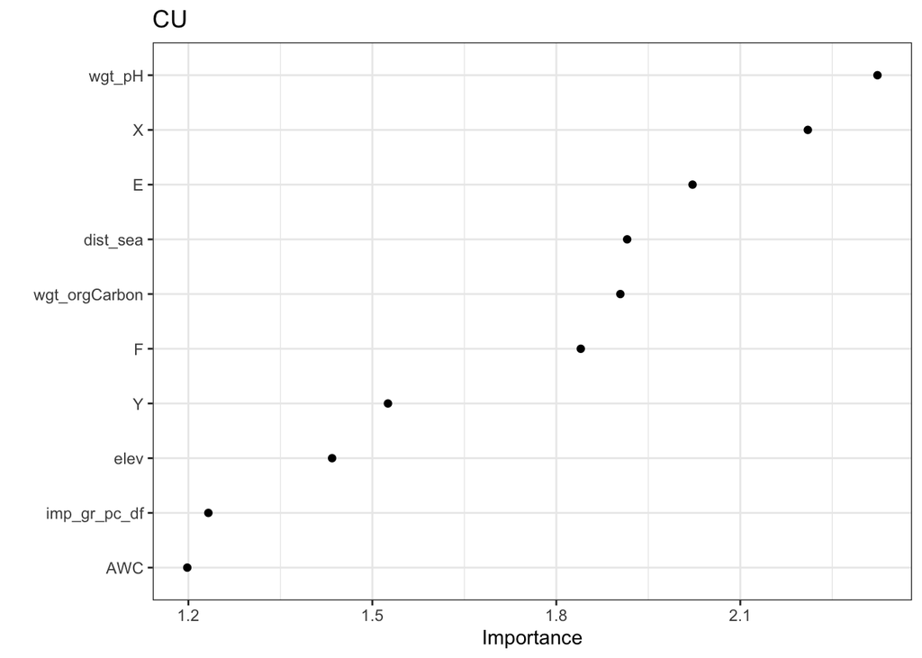

Variable importance in model fit

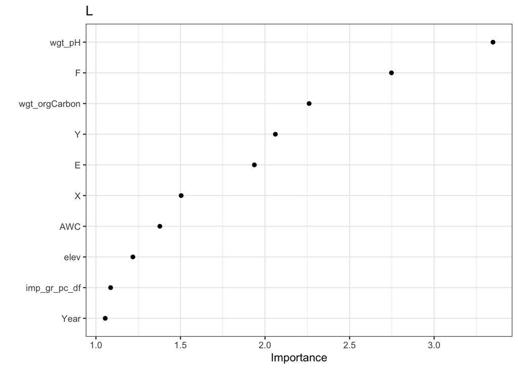

Variable importance in model fit

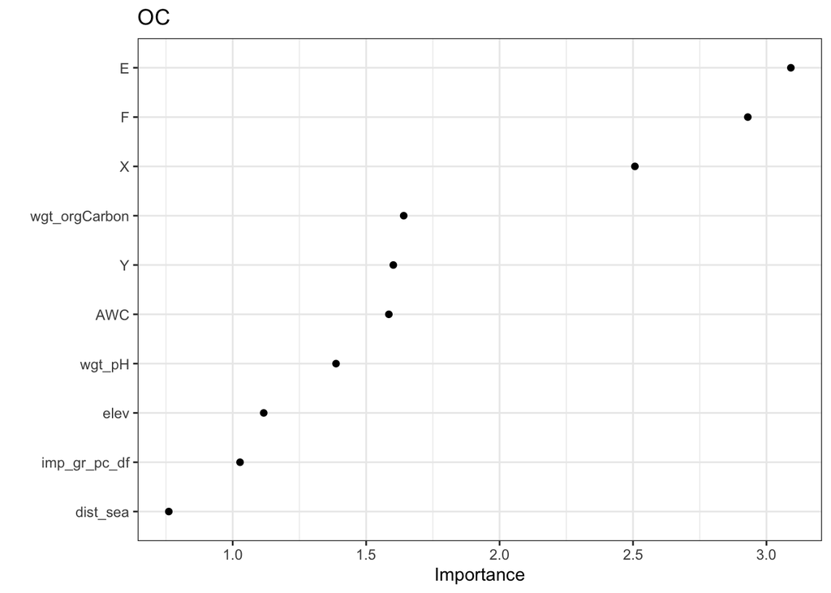

Variable importance in model fit

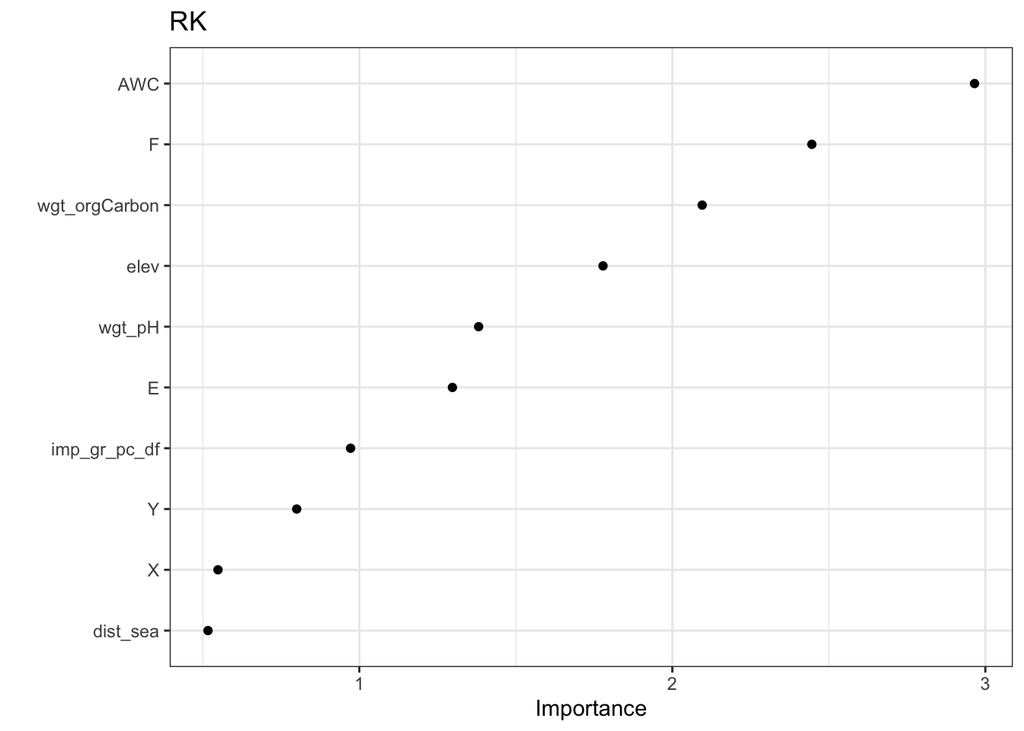

Variable importance in model fit

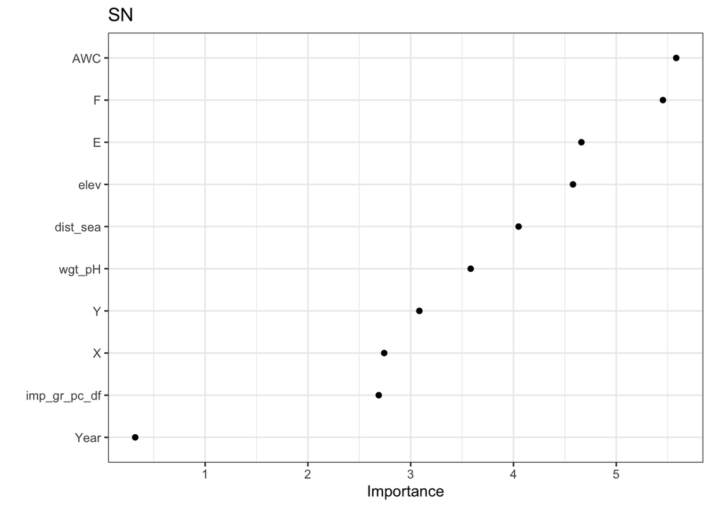

Variable importance in model fit

It can be seen that pH, X (longitude) and grassland percentage coverage for a given OS 1km square are the most important covariates for predicting abundance in Curlew. For Lapwing, pH, heathland percentage coverage and topsoil organic carbon content are the most important variables. Whilst for Oystercatcher, grassland and heathland percentage cover are almost equivalent in their importance followed by longitude. For Redshank and Snipe, available water capacity and heathland are the most important covariates in predicting abundance.

### Generate population estimate over time

The random forest regression model was used to predict species abundance over *all* (n=3992) Shetland BBS 1km squares. The model gave a mean estimate together with lower and upper confidence intervals (5% and 95% percentiles respectively), across every year the survey was run (2002 to 2019). The results are shown in Table @ref(tab:abundanceResults) and plotted Figure @ref(fig:plotAbunResults)

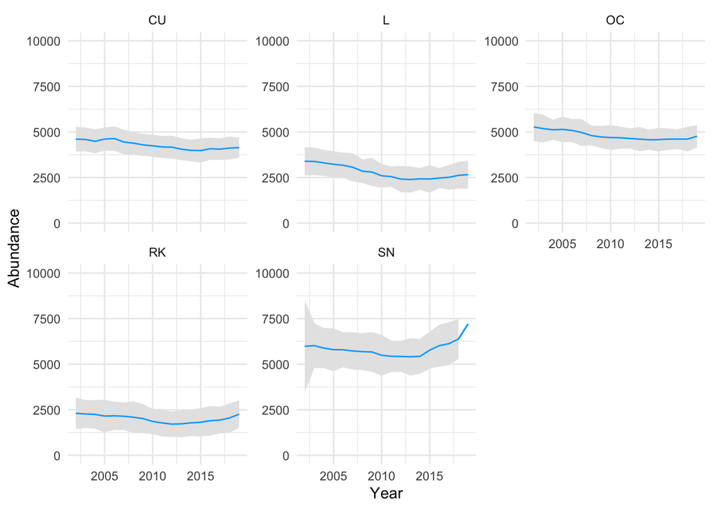

Shetland breeding wader abundance by year

Across the years 2002 to 2019 the abundance of breeding waders across all species appear to have decreased, with the exception of Snipe. The most significant decline was breeding Lapwing abundance. Note that the confidence intervals for Snipe are highly variable in certain years. Table @ref(tab:popChgTable) shows the change in breeding wader abundance by species between 2002 and 2019.

| Species | 2002 | 2019 | % Change |
| --- | --- | --- | --- |
| CU | 4597 | 4088 | -11.1 |
| L | 3474 | 2638 | -24.1 |
| OC | 5269 | 4760 | -9.7 |
| RK | 2390 | 2248 | -5.9 |
| SN | 6043 | 7391 | 22.3 |

### Lapwing abundance association with grassland holdings

Data from 2002 to 2017 for grassland holdings in hectares categorised as: tillage, grassland less than five years old (reseeded grassland), grassland five years or greater and private grazing were tested for normality, and found to be log-normally distributed. A linear regression was plotted for Lapwing abundance versus each grassland categorisation (in Hectares) as shown in Figure @ref(fig:lapwingGrasslandPlot).

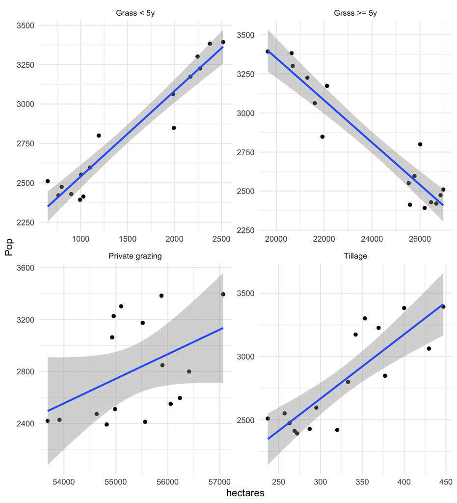

Association between the size of grassland categories on Shetland and Lapwing population abundance

Figure @ref(fig:lapwingGrasslandPlot) show’s that Lapwing population size is clearly positively associated with the size of grassland that is less than five years old (that grassland which has been reseeded) and tillage (land prepared for spring crops). Futhermore, Figure @ref(fig:lapwingGrasslandPlot) shows that Lapwing population abundance is negatively associated with grassland that is not reseeded (Grass >= 5y).

The `r` package `gamlss` was used to fit a log-normal model for Lapwing population abundance with grassland less than 5 years old as a covariate. The grassland < 5 years old was statistically significant covariate (p<0.0001), and the residuals of the model were approximately normally distributed as shown in Figure @ref(fig:fitLapwingModel).

```
## GAMLSS-RS iteration 1: Global Deviance = 192.9757
## GAMLSS-RS iteration 2: Global Deviance = 192.9757
```

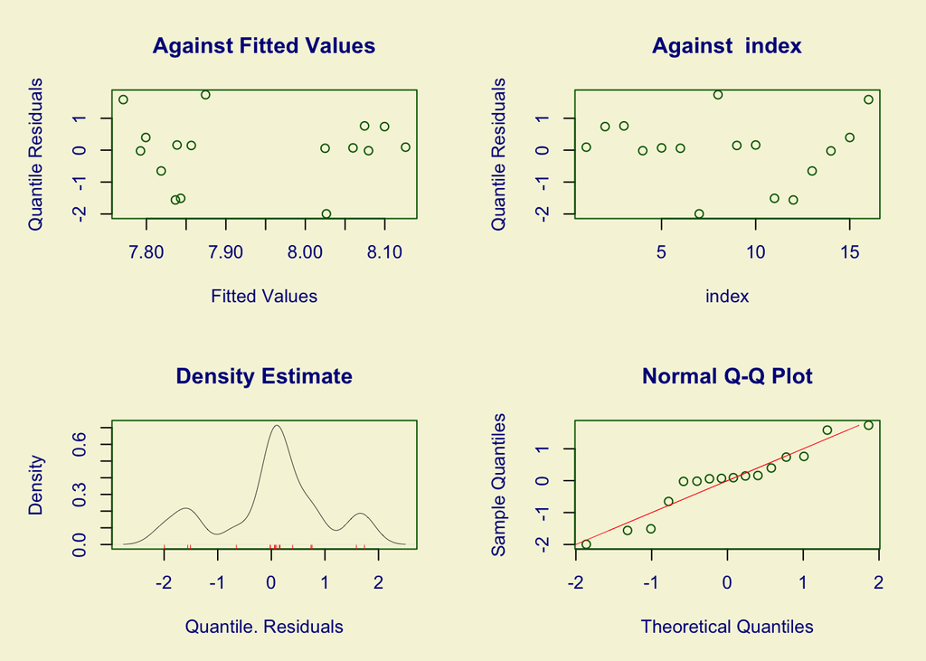

```
##        Summary of the Quantile Residuals
##                            mean   =  4.67573e-15
##                        variance   =  1.066667
##                coef. of skewness  =  -0.3010934
##                coef. of kurtosis  =  2.375124
## Filliben correlation coefficient  =  0.9630635
```

### Spatial abundance distriution

The abundance prediction created above is spatial and so can be plotted to show how species abundance is spatially distributed across Shetland. Figure @ref(fig:spatialDistributions) shows abundance distribution for each species in 2019.

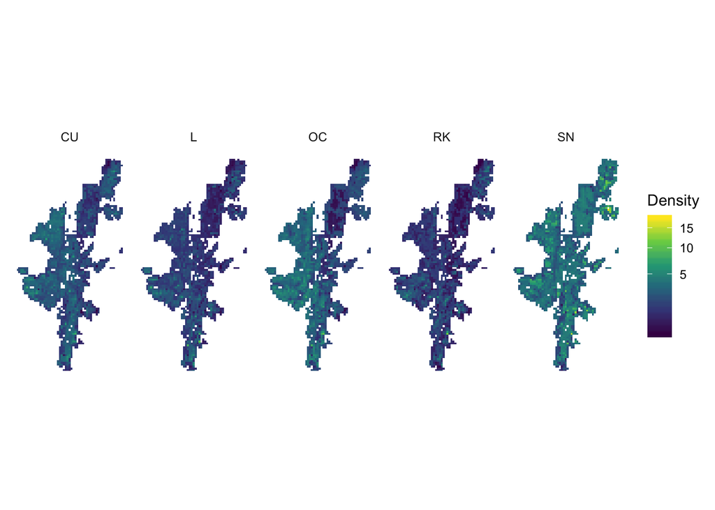

### Net abundance change by species between 2002 and 2019

Given the spatial abundance distribution for 2002 and 2019, it is possible to plot the net change in breeding wader abudnance between the two years. This is shown in Figure @ref(fig:netChgPlot).

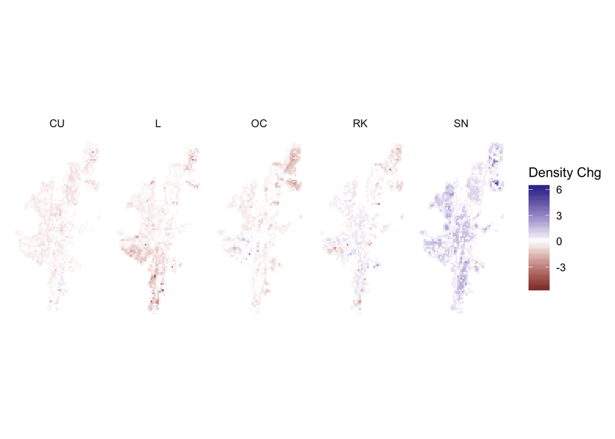

Change in breeding wader density (count/km2)

It can be seen that the drop in abundance as shown in Table @ref(tab:popChgTable) is reflected in the net change plots. Significant increases for Snipe, but significant Lapwing density declines in the south mainland, and Oystercatcher across Unst and Fetlar.